```python
#Name:Sadia Ali Watara
#ID Number:00305111
#Project 2
```

# Twitter Sentiment Analysis

```python
#Import Libraries
import numpy as np                #For numerical operations on large arrays of data.
import pandas as pd           #Provides data structures like dataFrames and series, which are useful for handling tabular data.
import matplotlib.pyplot as plt  #Provides a simple interface to create a variety of charts, plots and graphs.
import tensorflow as tf         #Used for building and training machine learning models, especially deep neural networks.
from sklearn.model_selection import train_test_split  #Is a function from scikit-learn that allows splitting a dataset into training and testing subsets.
import keras  # For enabling fast experimentation and easy-to-use syntax for building deep learning models.
import re    #It provides functions that enable you to use regular expressions in the Python code.
import string #provides a set of functions and constants that are helpful when working with strings.

from nltk.corpus import stopwords #Helps to remove a list of  stopwords from text data
from nltk.tokenize import word_tokenize  #Helps to split a sentence into individual words, removing any punctuation and whitespace.
from nltk.stem import PorterStemmer  #for converting words to their base form.
from nltk.stem import WordNetLemmatizer #helps to normalize words and reduce the dimensionality of text data


from sklearn.metrics import accuracy_score  # A performance metric used to evaluate the accuracy of a classification model
from sklearn.naive_bayes import MultinomialNB #used to train a Naive Bayes model on a small training dataset


import warnings # provides a way to handle warnings that occur during execution of a program
warnings.filterwarnings("ignore")
```

```python
#loading the dataset
url = "https://www.kaggle.com/datasets/kazanova/sentiment140" #source of the dataset
df = pd.read_csv("training.1600000.processed.noemoticon.csv",encoding = "latin",header=None)
```

```python
df
```

|  | 0 | 1 | 2 | 3 | 4 | 5 |
| --- | --- | --- | --- | --- | --- | --- |
| 0 | 0 | 1467810369 | Mon Apr 06 22:19:45 PDT 2009 | NO_QUERY | _TheSpecialOne_ | @switchfoot http://twitpic.com/2y1zl - Awww, t... |
| 1 | 0 | 1467810672 | Mon Apr 06 22:19:49 PDT 2009 | NO_QUERY | scotthamilton | is upset that he can't update his Facebook by ... |
| 2 | 0 | 1467810917 | Mon Apr 06 22:19:53 PDT 2009 | NO_QUERY | mattycus | @Kenichan I dived many times for the ball. Man... |
| 3 | 0 | 1467811184 | Mon Apr 06 22:19:57 PDT 2009 | NO_QUERY | ElleCTF | my whole body feels itchy and like its on fire |
| 4 | 0 | 1467811193 | Mon Apr 06 22:19:57 PDT 2009 | NO_QUERY | Karoli | @nationwideclass no, it's not behaving at all.... |
| ... | ... | ... | ... | ... | ... | ... |
| 1599995 | 4 | 2193601966 | Tue Jun 16 08:40:49 PDT 2009 | NO_QUERY | AmandaMarie1028 | Just woke up. Having no school is the best fee... |
| 1599996 | 4 | 2193601969 | Tue Jun 16 08:40:49 PDT 2009 | NO_QUERY | TheWDBoards | TheWDB.com - Very cool to hear old Walt interv... |
| 1599997 | 4 | 2193601991 | Tue Jun 16 08:40:49 PDT 2009 | NO_QUERY | bpbabe | Are you ready for your MoJo Makeover? Ask me f... |
| 1599998 | 4 | 2193602064 | Tue Jun 16 08:40:49 PDT 2009 | NO_QUERY | tinydiamondz | Happy 38th Birthday to my boo of alll time!!! ... |
| 1599999 | 4 | 2193602129 | Tue Jun 16 08:40:50 PDT 2009 | NO_QUERY | RyanTrevMorris | happy #charitytuesday @theNSPCC @SparksCharity... |

1600000 rows × 6 columns

```python
# Change the column names in the dataframe
df.columns = ["sentiment",'id',"date_time","query","user_id","tweet"]
print(df.columns)
```

```
Index(['sentiment', 'id', 'date_time', 'query', 'user_id', 'tweet'], dtype='object')
```

```python
df
```

|  | sentiment | id | date_time | query | user_id | tweet |
| --- | --- | --- | --- | --- | --- | --- |
| 0 | 0 | 1467810369 | Mon Apr 06 22:19:45 PDT 2009 | NO_QUERY | _TheSpecialOne_ | @switchfoot http://twitpic.com/2y1zl - Awww, t... |
| 1 | 0 | 1467810672 | Mon Apr 06 22:19:49 PDT 2009 | NO_QUERY | scotthamilton | is upset that he can't update his Facebook by ... |
| 2 | 0 | 1467810917 | Mon Apr 06 22:19:53 PDT 2009 | NO_QUERY | mattycus | @Kenichan I dived many times for the ball. Man... |
| 3 | 0 | 1467811184 | Mon Apr 06 22:19:57 PDT 2009 | NO_QUERY | ElleCTF | my whole body feels itchy and like its on fire |
| 4 | 0 | 1467811193 | Mon Apr 06 22:19:57 PDT 2009 | NO_QUERY | Karoli | @nationwideclass no, it's not behaving at all.... |
| ... | ... | ... | ... | ... | ... | ... |
| 1599995 | 4 | 2193601966 | Tue Jun 16 08:40:49 PDT 2009 | NO_QUERY | AmandaMarie1028 | Just woke up. Having no school is the best fee... |
| 1599996 | 4 | 2193601969 | Tue Jun 16 08:40:49 PDT 2009 | NO_QUERY | TheWDBoards | TheWDB.com - Very cool to hear old Walt interv... |
| 1599997 | 4 | 2193601991 | Tue Jun 16 08:40:49 PDT 2009 | NO_QUERY | bpbabe | Are you ready for your MoJo Makeover? Ask me f... |
| 1599998 | 4 | 2193602064 | Tue Jun 16 08:40:49 PDT 2009 | NO_QUERY | tinydiamondz | Happy 38th Birthday to my boo of alll time!!! ... |
| 1599999 | 4 | 2193602129 | Tue Jun 16 08:40:50 PDT 2009 | NO_QUERY | RyanTrevMorris | happy #charitytuesday @theNSPCC @SparksCharity... |

1600000 rows × 6 columns

# Data Cleaning and text Preprocessing

```python
#Shape of dataset
df.shape
```

```
(1600000, 6)
```

```python
#povides information about the data
df.info()
```

```
<class 'pandas.core.frame.DataFrame'>
RangeIndex: 1600000 entries, 0 to 1599999
Data columns (total 6 columns):
 #   Column     Non-Null Count    Dtype
---  ------     --------------    -----
 0   sentiment  1600000 non-null  int64
 1   id         1600000 non-null  int64
 2   date_time  1600000 non-null  object
 3   query      1600000 non-null  object
 4   user_id    1600000 non-null  object
 5   tweet      1600000 non-null  object
dtypes: int64(2), object(4)
memory usage: 73.2+ MB
```

```python
# Column Data type
df.dtypes
```

```
sentiment     int64
id            int64
date_time    object
query        object
user_id      object
tweet        object
dtype: object
```

```python
#used to count the number of rows in the dataFrame that contain at least one missing (null) value.
np.sum(df.isnull().any(axis=1))
```

```
0
```

```python
#Checking the distribution of the sentiments in our dataset
df['sentiment'].value_counts()
```

```
0    800000
4    800000
Name: sentiment, dtype: int64
```

```python
# The aim with this dataset is to classify sentiment so lets drop some columns that we dont need.
cleaned_df = df.drop(['id','date_time','query','user_id'], axis=1)
cleaned_df.head()
```

|  | sentiment | tweet |
| --- | --- | --- |
| 0 | 0 | @switchfoot http://twitpic.com/2y1zl - Awww, t... |
| 1 | 0 | is upset that he can't update his Facebook by ... |
| 2 | 0 | @Kenichan I dived many times for the ball. Man... |
| 3 | 0 | my whole body feels itchy and like its on fire |
| 4 | 0 | @nationwideclass no, it's not behaving at all.... |

```python
#Mapping positive sentiment from 4 to 1 for easier understanding.
cleaned_df['sentiment'] = cleaned_df['sentiment'].replace(4,1)

# Lowering case
def funLowercase(text):
    return text.lower()

cleaned_df['tweet'] = cleaned_df['tweet'].apply(funLowercase)
cleaned_df.head()
```

|  | sentiment | tweet |
| --- | --- | --- |
| 0 | 0 | @switchfoot http://twitpic.com/2y1zl - awww, t... |
| 1 | 0 | is upset that he can't update his facebook by ... |
| 2 | 0 | @kenichan i dived many times for the ball. man... |
| 3 | 0 | my whole body feels itchy and like its on fire |
| 4 | 0 | @nationwideclass no, it's not behaving at all.... |

```python
#Identifying duplicate tweets
unique_tweets = set()
duplicate_tweets = []
duplicate_tweets_iloc = []

# iterate through tweets and check for duplicates

for i in range(len(cleaned_df.tweet)):

    if cleaned_df.tweet[i] in unique_tweets:

        duplicate_tweets.append(cleaned_df.tweet[i])
        duplicate_tweets_iloc.append(i)

    else:
        unique_tweets.add(cleaned_df.tweet[i])

if duplicate_tweets_iloc :
    print(f'{len(duplicate_tweets_iloc)} Duplicate tweets found and location captured ')
else :
    print('No Duplicate Found')
```

```
22557 Duplicate tweets found and location captured
```

```python
# Removing Duplicate Tweets
cleaned_df.drop(index=duplicate_tweets_iloc, axis=0 , inplace=True)
```

```python
#Resetting Index and checking shape for count
cleaned_df.reset_index(inplace=True)
cleaned_df.shape
```

```
(1577443, 3)
```

```python
# The regular expression pattern to find Retweets
pattern1 = "^rt @[a-zA-Z0-9_]+:"
pattern2 = "^retweet @[a-zA-Z0-9_]+:"

# Use the search() method to check if the pattern is in the tweet
retweet_iloc = []
for i in range(len(cleaned_df.tweet)):

    match1 = re.search(pattern1, cleaned_df.tweet[i])
    if match1:
        retweet_iloc.append(i)

    match2 = re.search(pattern2, cleaned_df.tweet[i])
    if match2:
        retweet_iloc.append(i)

if retweet_iloc :
    print(f'{len(retweet_iloc)} retweets found and location captured' )
else :
    print('No Retweet Found')
```

```
25 retweets found and location captured
```

```python
# Removing Retweets
cleaned_df.drop(index=retweet_iloc, axis=0 , inplace=True)
```

```python
#Resetting Index and checking shape for count
cleaned_df.reset_index(inplace=True)
cleaned_df.shape
```

```
(1577418, 4)
```

```python
#Checking final Count of Tweets after Removal
cleaned_df['sentiment'].value_counts()     #sns.countplot(x='sentiment' , data=cleaned_df)
```

```
1    789461
0    787957
Name: sentiment, dtype: int64
```

```python
import time  #provides a set of functions to work with time-related tasks,
import nltk  #provides a set of tools and resources for working with human language data
from nltk.tokenize import TweetTokenizer  #provides a set of functions for tokenizing text into words, sentences,and linguistic units.
t = time.process_time()

# Initialize the tweet tokenizer with reduce_len parameter to limit repeating consecutive characters to max 3 .
tweet_tokenizer = TweetTokenizer(reduce_len=True)

# Tokenize text using the TweetTokenizer

cleaned_df['tokenizer_tweets'] = cleaned_df['tweet'].apply(tweet_tokenizer.tokenize)

print(f'Tokenization Finished !')
print(f'CPU Time Taken: {round(time.process_time()-t)} seconds')
```

```
Tokenization Finished !
CPU Time Taken: 111 seconds
```

```python
# provides the cleaned and tokenized text data.
cleaned_df.tokenizer_tweets[11]
```

```
['i', 'just', 're-pierced', 'my', 'ears']
```

From the code below,the 'averaged_perceptron_tagger' model is a machine learning model that is trained on a large corpus of text to assign POS tags to words in a sentence. This model is widely used for natural language processing tasks such as text classification, sentiment analysis, and information retrieval.

After downloading the required NLTK datasets,I applyied the 'tweet_cleaner' function to each tweet in the 'tokenizer_tweets' column of the 'cleaned_df' DataFrame, and storing the cleaned tweets in a new column called 'cleaned_tweets'.

```python
import nltk
nltk.download('stopwords')
# Defining Stopwords
STOPWORDS = stopwords.words('english')

def tweet_cleaner(tweet_tokens):

    cleaned_tokens = []

    for token, tag in pos_tag(tweet_tokens):

        #Removing links
        token = re.sub('http[s]?://(?:[a-zA-Z]|[0-9]|[$-_@.&+#]|[!*\(\),]|'\
                       '(?:%[0-9a-fA-F][0-9a-fA-F]))+','', token)

        #Removing mentions
        token = re.sub("(@[A-Za-z0-9_]+)","", token)

        # Checking for POS label and converting it for Lemmatizer input
        if tag.startswith("NN"):
            pos = 'n'
        elif tag.startswith('VB'):
            pos = 'v'
        else:
            pos = 'a'

        #Init Lemmatizer
        tweet_lemmatizer = WordNetLemmatizer()
        cleaned_token = tweet_lemmatizer.lemmatize(token, pos)

        #Checking for punctuation, word lenght less than 2 then removing stopwords
        if cleaned_token not in string.punctuation and len(cleaned_token) > 2 and cleaned_token not in STOPWORDS:
            cleaned_tokens.append(cleaned_token)

    return cleaned_tokens
```

```python
import nltk
nltk.download('wordnet')
from nltk import pos_tag  # provides a tuple that contains a word from the input list and its corresponding part-of-speech tag

nltk.download('averaged_perceptron_tagger')
t = time.process_time()

nltk.download('omw-1.4')
cleaned_df['cleaned_tweets'] = cleaned_df['tokenizer_tweets'].apply(tweet_cleaner)

print(f'Cleaning Finished !')
print(f'CPU Time Taken: {round(time.process_time()-t)} seconds')
```

```
Cleaning Finished !
CPU Time Taken: 1340 seconds
```

```python
print(cleaned_df['tokenizer_tweets'][1])
print(cleaned_df['cleaned_tweets'][1])
```

```
['is', 'upset', 'that', 'he', "can't", 'update', 'his', 'facebook', 'by', 'texting', 'it', '...', 'and', 'might', 'cry', 'as', 'a', 'result', 'school', 'today', 'also', '.', 'blah', '!']
['upset', "can't", 'update', 'facebook', 'texting', '...', 'might', 'cry', 'result', 'school', 'today', 'also', 'blah']
```

```python
# Splitting positive and negative words

pos_words = []
neg_words = []

for i in range(len(cleaned_df['cleaned_tweets'])):
    if cleaned_df['sentiment'][i] == 1:
        pos_words.extend(cleaned_df['cleaned_tweets'][i])
    else:
        neg_words.extend(cleaned_df['cleaned_tweets'][i])
```

```
WordCloud for Positive words
```

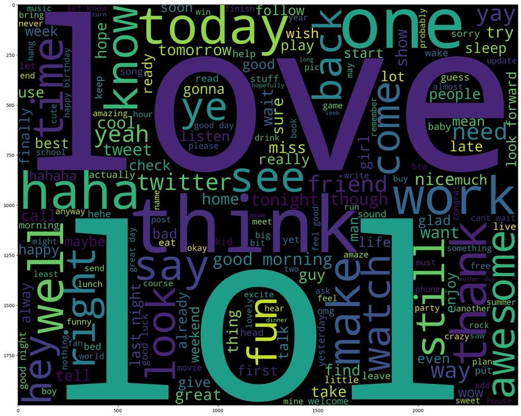

```python
# Word Cloud for Positive Tweets
!pip install wordcloud
from wordcloud import WordCloud


print('WordCloud for Positive words')
wc = WordCloud(width = 2500 , height = 2000).generate(" ".join(pos_words))
plt.figure(figsize = (20,20))
plt.imshow(wc)
```

```
WordCloud for Negative words
```

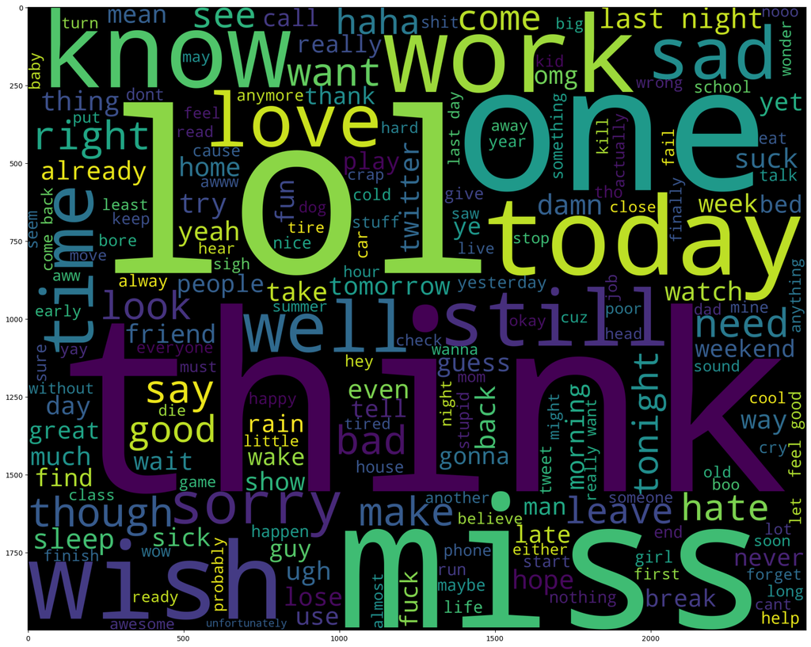

```python
# Word Cloud for Negative Tweets

print('WordCloud for Negative words')
wc = WordCloud(width = 2500 , height = 2000).generate(" ".join(neg_words))
plt.figure(figsize = (20,20))
plt.imshow(wc)
```

# Building the model

```python
# splits the cleaned tweets data into training and test sets
X, y = np.array(cleaned_df['cleaned_tweets']),np.array(cleaned_df['sentiment'])

X_train, X_test, y_train, y_test = train_test_split(X, y, test_size = 0.2, random_state = 0)
print('Data Splitting Completed.')
```

```
Data Splitting Completed.
```

```python
from gensim.models import Word2Vec  #used it to generate vector representations of words.
t = time.process_time()

# Define the parameters for the Word2Vec model
size = 100 # Dimensionality of the word vectors
window = 5 # Maximum distance between the current and predicted word within a sentence
min_count = 5 # Minimum count of words to consider in the vocabulary
workers = 4 # Number of threads to use for training the

# Train the Word2Vec model
word2vec_model = Word2Vec(X_train, vector_size=size, window=window, min_count=min_count, workers=workers)

print(f'Word2Vec Training Finished !')
print(f'CPU Time Taken: {round(time.process_time()-t)} seconds')
print(f'Vocabulary Length!' , len(word2vec_model.wv.key_to_index))
```

```
Word2Vec Training Finished !
CPU Time Taken: 27 seconds
Vocabulary Length! 41547
```

```python
from tensorflow.keras.preprocessing.text import Tokenizer
from tensorflow.keras.preprocessing.sequence import pad_sequences
t = time.process_time()

input_length = 60
vocab_length = 60000

tokenizer = Tokenizer(filters="", lower=False, oov_token="<oov>")
tokenizer.fit_on_texts(X)
tokenizer.num_words = vocab_length

X_train = pad_sequences(tokenizer.texts_to_sequences(X_train), maxlen=input_length)
X_test  = pad_sequences(tokenizer.texts_to_sequences(X_test) , maxlen=input_length)

print(f'Padding Dataset Finished !')
print(f'CPU Time Taken: {round(time.process_time()-t)} seconds')
```

```
Padding Dataset Finished !
CPU Time Taken: 15 seconds
```

From the code below,the embedding matrix has a shape of (60000, 100), meaning that it contains word embeddings for 60000 unique words, where each word embedding has a dimension of 100. The embedding matrix is initialized with zeros, and for each word in the tokenizer's word index that exists in the Word2Vec model's vocabulary, the corresponding row in the embedding matrix is updated with the Word2Vec embedding vector for that word.

```python
embedding_matrix = np.zeros((vocab_length, size))

for word, token in tokenizer.word_index.items():
    if word2vec_model.wv.__contains__(word):
        embedding_matrix[token] = word2vec_model.wv.__getitem__(word)


print("Embedding Matrix Shape:", embedding_matrix.shape)
```

```
Embedding Matrix Shape: (60000, 100)
```

```python
from keras.layers import Embedding
embedding_layer = Embedding(input_dim = vocab_length,
                                output_dim = size,
                                weights=[embedding_matrix],
                                input_length=input_length,
                                trainable=False)
```

The code below defines a Bidirectional LSTM model using the Keras API. It is a type of Recurrent Neural Network (RNN) model architecture that consists of an embedding layer, two Bidirectional LSTM layers with 128 units each, and a Dense layer with a sigmoid activation function that outputs a single value. LSTMs are capable of learning long-term dependencies in sequential data and are widely used in various natural language processing (NLP) tasks, such as language modeling and sentiment analysis.

The input shape to the model is (batch_size, input_length), where batch_size is the number of samples in each batch and input_length is the length of each input sequence (in this case, 60).

The output shape of the model is (batch_size, 1), which corresponds to a single binary classification output.

```python
from tensorflow.keras.layers import Bidirectional
from keras.layers import LSTM
def BiLSTM_Model():
    model = Sequential([
        embedding_layer,
        Bidirectional(LSTM(units=128, return_sequences=True)),
        Bidirectional(LSTM(units=128, return_sequences=False)),
        Dense(units=1, activation='sigmoid')
    ],
    name='BiLSTM_Model')
    return model
```

```python
#Summary of LSTM model
from keras.models import Sequential
from keras.layers import Dense, Embedding, Bidirectional, LSTM
model = BiLSTM_Model()
model.summary()
```

```
Model: "BiLSTM_Model"
_________________________________________________________________
 Layer (type)                Output Shape              Param #
=================================================================
 embedding_1 (Embedding)     (None, 60, 100)           6000000

 bidirectional_2 (Bidirectio  (None, 60, 256)          234496
 nal)

 bidirectional_3 (Bidirectio  (None, 256)              394240
 nal)

 dense_1 (Dense)             (None, 1)                 257

=================================================================
Total params: 6,628,993
Trainable params: 628,993
Non-trainable params: 6,000,000
_________________________________________________________________
```

The loss parameter is set to 'binary_crossentropy', which is a commonly used loss function for binary classification problems. The goal of this function is to measure the difference between the true labels and the predicted labels of the model.

The optimizer parameter is set to an instance of the Adam optimizer, which is a commonly used optimization algorithm for deep learning models. The lr parameter of the Adam optimizer is set to 0.001, which controls the learning rate of the optimizer.